# Possible Analyses for Revisions

## Overview

Using data collected on infestation by the spotted laternfly across 166 counties in the Mid-Atlantic region of the United States, we are interested to know about factors that likely contribute to spread of the organism. Here, we focus on factors related to human activity and that can be targeted for control or mitigation measures. The factors we focus on are:

- The number of businesses designated as garden centers in a county.
- The number of two-digit interstate highways that transect a county.

Further, we also examine the influence of the county population as previous work has established this as an important contributor to lanternfly spread.

A reasonable question: does the data provide evidence that the transportation of materials sold at garden centers over interstate highways contribute to the spread of the spotted laternfly?

## The Data

Table 1 displays the first few rows of the data collected for the 166 county Mid-Atlantic region.

Table 1: Data collected for the 166 county Mid-Atlantic region.

| infested | year | county | state | nis | gc | pop |
| --- | --- | --- | --- | --- | --- | --- |
| 0 | 2014 | suffolk | NY | 0 | 39 | 1477000 |
| 0 | 2014 | nassau | NY | 0 | 18 | 1357000 |
| 0 | 2014 | fairfield | CT | 2 | 30 | 943332 |
| 0 | 2014 | ocean | NJ | 0 | 24 | 607186 |
| 0 | 2014 | queens | NY | 0 | 12 | 2253858 |
| 0 | 2014 | kings | NY | 0 | 21 | 2559903 |

For analysis, we add to this data the boundaries for all included counties.

Figure 1 displays the 2021 infestation status for the 166 Mid-Atlantic region counties in 2021:

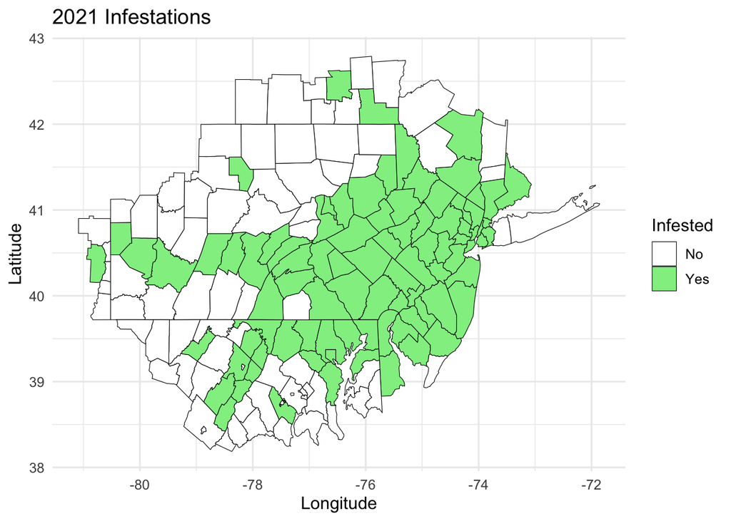

Figure 1: Counties in the defined Mid-Atlantic regions that were designated as infested by the spotted laternfly in 2021.

## Initial Exploratoration of the Data

Table 2 displays the number of counties per year in the defined Mid-Atlantic region of 166 that were listed as infected.

Table 2: The number of counties per year in the defined Mid-Atlantic region of 166 that were listed as infected.

| Year | Number Infested |
| --- | --- |
| 2014 | 1 |
| 2015 | 4 |
| 2016 | 6 |
| 2017 | 6 |
| 2018 | 18 |
| 2019 | 26 |
| 2020 | 50 |
| 2021 | 88 |

Figure 2 shows the 166 counties in the defined Mid-Atlantic region together with their 2021 infestation status and the number of two-digit interstate highways that transect the county.

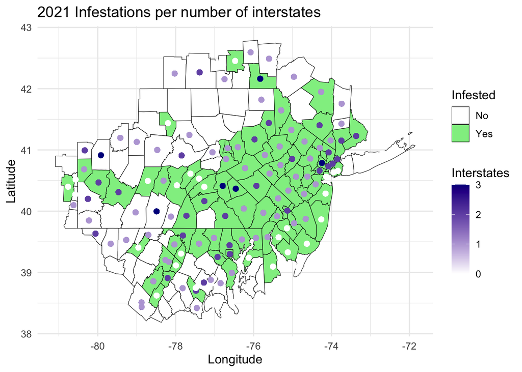

Figure 2: Spotted laternfly infested counties for 2021 together with the number of two-digit interstate highways transecting the counties.

Figure 3 shows the 166 counties in the defined Mid-Atlantic region together with their 2021 infestation status and the number of garden centers in the county.

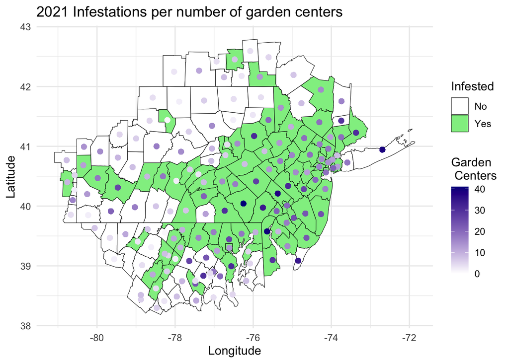

Figure 3: Spotted laternfly infested counties for 2021 together with the number of garden centers in the counties.

Figure 4 shows the 166 counties in the defined Mid-Atlantic region together with their 2021 infestation status and the county population on the log scale as estimated in 2019.

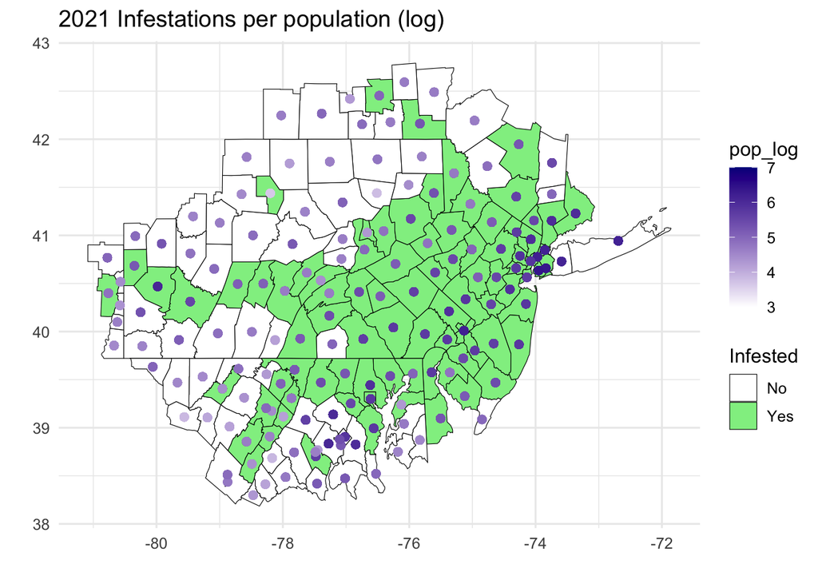

Figure 4: Spotted laternfly infested counties for 2021 together with the 2019 estimated population (log scale) for the counties.

[figure not shown]

## Statistical Analysis

### 2021 Only Data

For a statistical test of our hypothesis, we have use R version 4.3.1 and package `mgcv` to fit a generalized additive model (R Core Team 2023; S. N. Wood 2003; Simon N. Wood 2017). Specifically, we model the log odds of county infestation in 2021 with tensor product smoothing for longitude and latitude to control for spatial autocorrelation with linear predictors: presence/absence of two-digit interstate highway, number of garden centers, 2019 county population, and an interaction term for presence/absence of two-digit interstate highway and number of garden centers. To deal with issues of convergence and variables of different scale, we log transformed the population and centered and scaled the number of garden centers. We used the packages `DHARMa` and `gratia` for diagnostics of model assumptions (Hartig 2022 ; Simpson 2023).

```r
mod_form_21 <- infested ~ is_presence + std_gc + is_presence:std_gc + pop_log +
   te(longitude,latitude)

gam_mod_21 <- gam(mod_form_21,data=data_1,
                      family = binomial(),
                      method = "REML")
```

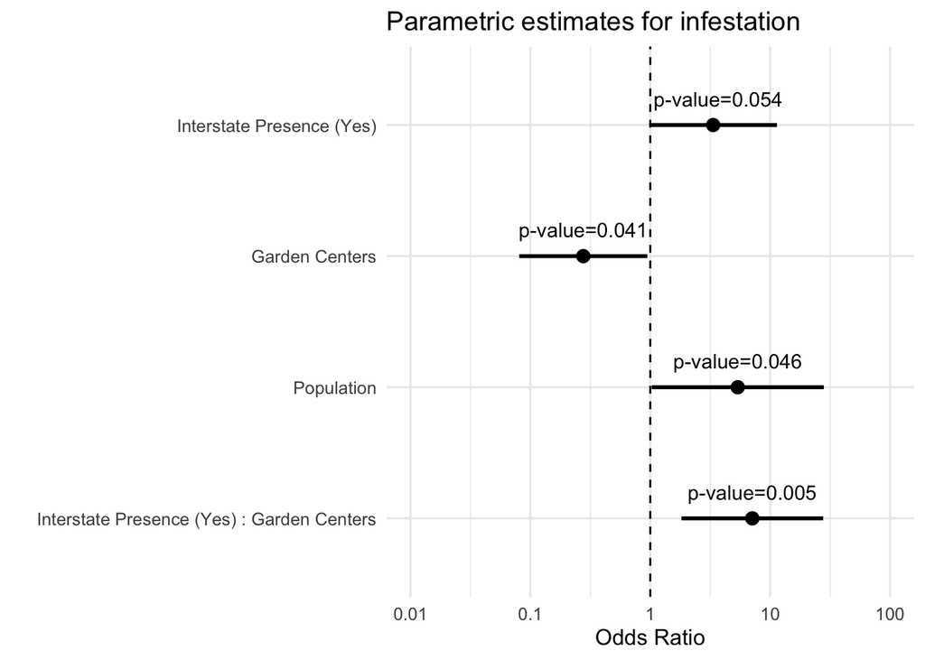

Figure 6: Estimated coefficients for the linear predictors in the generalized additive model. Results are on the scale of odds ratio.

```r
gam_mod_21_ests <- plot_model(gam_mod_21)$data %>%
  tibble() %>%
  mutate(coeff = factor(c("Interstate Presence (Yes)","Garden Centers","Population","Interstate Presence (Yes) : Garden Centers"),levels=c("Interstate Presence (Yes) : Garden Centers","Population","Garden Centers","Interstate Presence (Yes)")))

gam_mod_21_ests %>%
  ggplot(aes(x=log(estimate),y=coeff)) +
  geom_point(size=3) +
  geom_errorbar(aes(xmin=log(conf.low), xmax=log(conf.high)),
                width=0.0,
                 position=position_dodge(0.05),linewidth=1) +
  annotate(geom = "text", x = log(3.34)+0.1,y=4.2,label="p-value=0.054") +
  annotate(geom = "text", x = log(0.276),y=3.2,label="p-value=0.041") +
  annotate(geom = "text", x = log(5.37),y=2.2,label="p-value=0.046") +
  annotate(geom = "text", x = log(7.10),y=1.2,label="p-value=0.005") +
    scale_x_continuous(breaks = log(c(0.01,0.1,1.0,10.0,100.0)),
                       labels = c(0.01,0.1,1.0,10.0,100.0),
                       limits = log(c(0.01,100.0))) +
  labs(x = "Odds Ratio", y = "", title = "Parametric estimates for infestation") +
  geom_vline(xintercept = 0.0,linetype="dashed")
```

Table 3 summarizes the estimated coefficients for the linear predictors in the generalized additive model.

Table 3: Summary table for estimates for linear terms in generalized additive model. Results are on the log odds scale.

| Coefficient | Estimate | SE | p-value |
| --- | --- | --- | --- |
| Intercept | -8.794628 | 4.2781470 | 0.0398105 |
| Interstate Presence - Yes | 1.207274 | 0.6253652 | 0.0535437 |
| Garden Centers | -1.286439 | 0.6280036 | 0.0405151 |
| Population (log) | 1.679994 | 0.8431980 | 0.0463264 |
| Interstate Presence - Yes : Garden Centers | 1.959781 | 0.6944467 | 0.0047714 |

### Infestation Trend Over Time

```r
mod_form <- infested ~ is_presence + std_gc + is_presence:std_gc + pop_log +
   s(year_zero,k=8) + te(longitude_num,latitude_num)

gam_mod <- gam(mod_form,data=data_14_21,
                      family = binomial(),
                      method = "REML")
```

```r
mod_smooth_estimates <- smooth_estimates(gam_mod) %>%
  filter(smooth == "s(year_zero)")

mod_smooth_estimates_der <- derivatives(gam_mod,term = "s(year_zero)")
```

(Simpson 2023)

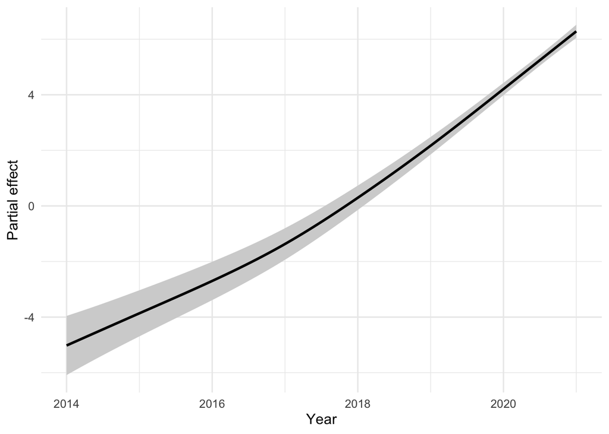

Figure 7: Partial effect plot for the log odds of infestation over time from 2014 - 2021.

```r
mod_smooth_estimates %>%
  ggplot(aes(x=year_zero + 2014,y=est)) +
  geom_ribbon(aes(ymin = est - se,ymax = est + se),fill="lightgray") +
  geom_line(linewidth=1) +
  labs(x = "Year", y = "Partial effect")
```

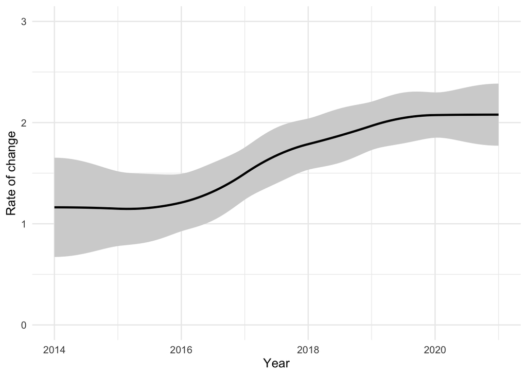

Figure 8: Time rate of change (i.e., first derivative) of partial effect of the log odds of infestation over time from 2014 - 2021.

```r
mod_smooth_estimates_der %>%
  ggplot(aes(x=data + 2014,y=derivative)) +
  geom_ribbon(aes(ymin = derivative - se,ymax = derivative + se),fill="lightgray") +
  geom_line(linewidth=1) +
  labs(x = "Year", y = "Rate of change") +
  ylim(c(0,3))
```

## References

Hartig, Florian. 2022. *DHARMa: Residual Diagnostics for Hierarchical (Multi-Level / Mixed) Regression Models*. https://CRAN.R-project.org/package=DHARMa.

R Core Team. 2023. *R: A Language and Environment for Statistical Computing*. Vienna, Austria: R Foundation for Statistical Computing. https://www.R-project.org/.

Simpson, Gavin L. 2023. *gratia: Graceful ggplot-Based Graphics and Other Functions for GAMs Fitted Using mgcv*. https://gavinsimpson.github.io/gratia/.

Wood, S. N. 2003. “Thin-Plate Regression Splines.” *Journal of the Royal Statistical Society (B)* 65 (1): 95–114.

Wood, Simon N. 2017. *Generalized Additive Models: An Introduction with r*. CRC press.